# Grading assignments with Quercus

## Log in to Quercus

… and find the course you’re grading assignments for. Click on Grades:

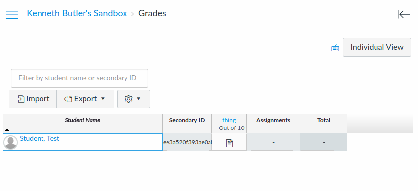

In this case, there is one student who has submitted one assignment, but of course normally there will be many more of both of those.

## To grade an assignment

Click on the title of the assignment, here Thing:

[figure not shown]

This gives you some information about the assignment, but the important thing is the link Speedgrader near the bottom. Click it. (There are other places to get to Speedgrader from; any of them is good.) That brings you to something like this:

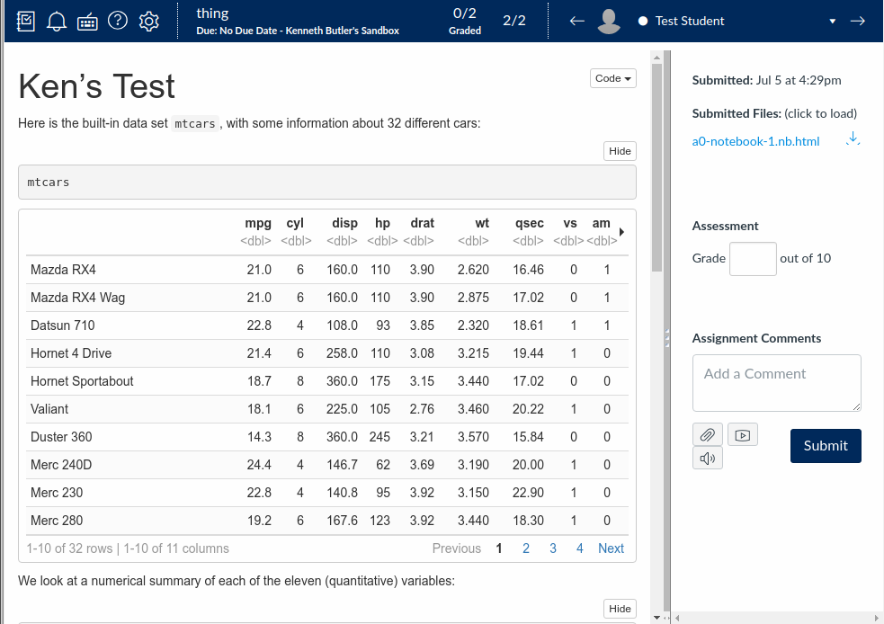

In STAC32, I have asked students to hand in the HTML output of an R Notebook. Other courses may be different. If the instructor has asked the students to hand in some kind of text file, you might see icons on the top left to insert comments or annotation. Those do not appear here. (A Word file appears not to preview on the left at all.) If a student has submitted something that doesn’t display, click the blue down-arrow top right to download it and then look at it. If the student has submitted more than one file (I ask them not to, but they might still do so), there will be more than one file under Submitted Files, and you can click on a different file to preview that one.

In this course, use the Assignment Comments box for all your comments. Label each comment with the question part, and, if necessary, the question number to which it belongs. A student needs to be clear about why they have lost every single mark. I would also like you to note any work that was done especially well. Put the final grade in the box. (This is by default released immediately to the student. See the section Showing and Hiding Grades below to change this.) You might be able to download a Word file and type on it, but I think it is still best to confine your comments to the Assignment Comments box. If you comment on a Word document, you’ll have to upload it again for the student to see what you wrote.)

A student may have made more than one submission (for example, because they realized they made an error the first time). In STAC32, I have asked that students who make more than one submission submit the *whole thing* again, and my instructions to you are to grade the last attempt only. (Use your discretion: if there is something in an earlier attempt and you can find it quickly, you can mark it, but with a warning.) I had my fictitious student submit something else, and I went back to the submission I graded before:

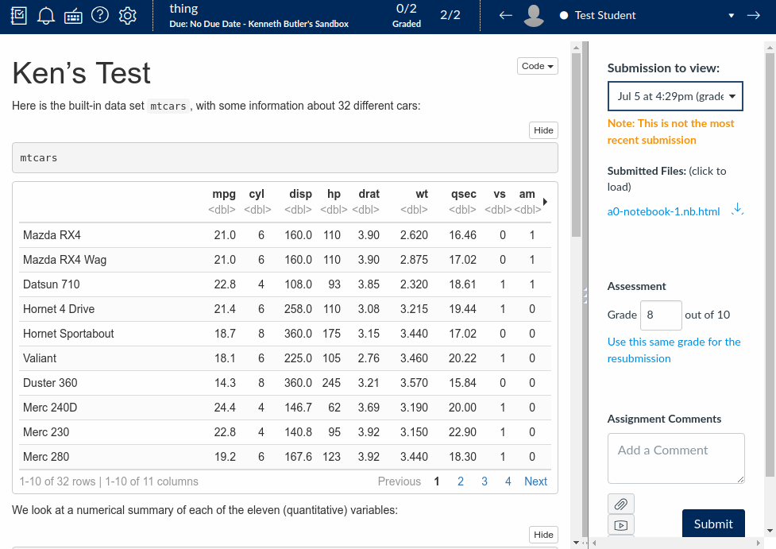

Now you see top right an extra pull-down with the dates and times of all that student’s submissions for this assignment. If the submission you are looking at is *not* the most recent one, you are warned of this in orange. You should generally be grading the most recent submission, in which case you won’t see the orange warning.

If you prefer, though I don’t think you will, you can download all the files submitted (though, when I tried it, it didn’t download the HTML file). These are stored in a zip file, with file names containing the student number (so it doesn’t matter if different students use the same filename in their submissions). After that, you can re-upload them.

## Showing and hiding grades

The default in Quercus is that students will be able to see their grades as soon as you have finished grading their assignment. Whether you think this is desirable will depend on how you work. For example, I like to go through everyone’s part (a), then go through everyone’s part (b), and so on. I sometimes use the Grade spot as a temporary reminder of how many marks the student has so far. In that situation, you wouldn’t want to have a student be able to see their mark until you were finished with everybody. On the other hand, if you mark a whole assignment at once, you might *prefer* for a student to see their mark as soon as you are finished. It is your choice as a grader which way you prefer to go.

Quercus’s mechanism for showing/hiding grades is called Mute and Unmute. An assignment starts by default as Unmuted, which means that a student can see their grade immediately. If an assignment is Muted, none of the students will be able to see their grade for that assignment (though they will be able to see everything *except* their grade).

To mute or unmute an assignment, find the heading in the Grades table for that assignment:

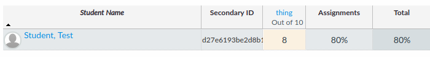

Hover over the header until a blue down arrow appears:

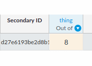

Click the blue down arrow and see a menu like this one appear:

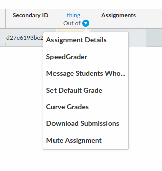

The bottom selection is where you mute an assignment that is currently unmuted, or unmute an assignment that is currently muted. (This menu provides another way to get at Speedgrader.)

I muted the assignment, and saw this:

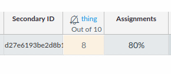

A muted assignment is shown with a crossed-out bell in its heading. When the assignment is unmuted, this disappears.

I echo the sentiment [here](https://community.canvaslms.com/docs/DOC-12961-4152724339): the *only* purpose for muting an assignment is that it has not been fully graded yet, and when you have finished grading it, make sure you unmute it.